# Take a Hike on the Perfect Trail for You!

Natalia Iannucci, Hana Hirano, and Syrine Matoussi

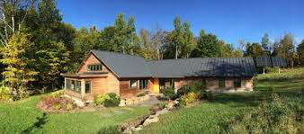

The Macleish Field station is situated in the hills of West Whately in the City of Northampton, Massachusetts. In 2013, Smith College donated a conservation restriction on 260 acres to Kestrel, in order to allow students to conduct environmental research, receive outdoor education and hike in the woods while also protecting the wildlife habitat for the future. In order to make it easier and more convenient for students to explore the Macleish woods, student volunteers began constructing nature trails on the property this summer. By the end of the summer, they successfully, cleared, raked and hacked their way through enough tree roots to complete nearly a mile of walkable trails for the proposed five-mile trail network.

The project began in 2008 when landscape studies design studio students worked with Bertone-Johnson to design an interpretive trail network that highlights the history and ecology of the site.The problem we are facing is that the trails currently are not classified in term of difficulty and visitors do not know what to expect when they choose a trail. In our project we are looking through the designed trails and trying to compute and rank their difficulty levels to give a clear idea of how difficult each trail is for visitors of [Macleish](https://www.smith.edu/insight/stories/macleish_sidebar.php). [^1] The following map shows the location, name and difficulty level of each trail.

```r
library(tidyverse)
library(macleish)
library(leaflet)
library(sf)
library(ggthemes)
library(ggrepel)
library(rgdal)

#get trails layer from macleish data set

trail_stream_xings <- macleish_layers %>%
  pluck("trails") %>%
  st_intersection(pluck(macleish_layers, "streams"))

boundary <- macleish_layers %>%
  pluck("boundary")
macleish_trails <- macleish_layers %>%
  pluck("trails")

interior_trails <- st_intersection(
  boundary,
  macleish_trails %>%
    filter(name %in% c("entry trail", "Western Loop", "Eastern Loop", "Porcupine Trail", "Vernal Pool Loop"))
)

trails_leaflet <- leaflet() %>%
  addTiles() %>%
  addPolylines(data = interior_trails)
```

```r
elevation <- macleish_layers %>%
  pluck("contours_3m") %>%
  st_transform(4326)
```

```r
#combine elevation and trail layers

elevation_trails <- st_intersection(
  interior_trails,
  elevation
) %>%
  select(name, SHAPE_LEN, geometry)
```

```r
grouped <- elevation_trails %>%
  filter(name %in% c("entry trail", "Western Loop", "Eastern Loop", "Vernal Pool Loop", "Porcupine Trail")) %>%
  group_by(name) %>%
  summarize(distance = sum(SHAPE_LEN))

grouped$elev_change <- c("78.740", "19.685", "98.425", "19.685", "137.795")
grouped$elev_change <- as.numeric(as.character(grouped$elev_change))

grouped <- grouped %>%
  mutate("Distance_miles" = distance / 5280) %>%
  mutate("Difficulty" = sqrt(elev_change * 2 * Distance_miles)) %>%
  select(name, elev_change, Distance_miles, Difficulty)

grouped$difficulty_level<-c("moderate", "easy", "moderate", "easy", "streneous")
```

```r
name_pal <- colorFactor(palette = rainbow(5), domain = macleish_trails$name)

hiking_trails<- macleish_trails %>%
  filter(name %in% c("entry trail", "Western Loop", "Eastern Loop", "Vernal Pool Loop", "Porcupine Trail")) %>%
  group_by(name)
  interior_trails$difficulty_level<- c("moderate","streneous","easy","moderate","streneous","streneous","easy","moderate")

name_map <- leaflet() %>%
  addTiles() %>%
  addPolylines(data = hiking_trails, color = ~name_pal((name))) %>%
  addLegend("bottomright", pal = name_pal, values = hiking_trails$name,
   title = "trail names",
  labels ="tail names",
   opacity = 1)%>%
  addMarkers(data = st_cast(interior_trails, "POINT"), popup = ~difficulty_level)
```

```r
elevation_graph <- ggplot(grouped, aes(x = Distance_miles, y = elev_change)) +
  geom_vline(xintercept = 2.5, color = "black", linetype = "dotted") +
  geom_rect(aes(xmin = 0, xmax= 2.5, ymin = 0, ymax = Inf), fill = "green", alpha = 0.08) +
  geom_vline(xintercept = 6, color = "black", linetype = "dotted") +
  geom_rect(aes(xmin =2.5, xmax= 6, ymin = 0, ymax = Inf), fill = "yellow", alpha = 0.08) +
  geom_rect(aes(xmin = 6, xmax = 7, ymin = 0, ymax = Inf), fill = "red", alpha = 0.08) +
  geom_smooth(method = 'loess') +
  geom_point(size = 5) +
  theme_solarized() +
  geom_smooth(color = "black", fill = "blue") +
  geom_label_repel(aes(label = name), point.padding = 0.5, hjust = "middle", vjust = "center") +
  xlab("Distance of Trail (in miles)") +
  ylab("Total change in elevation (in feet)") +
  labs(title = "Profiles of Trails in Macleish",face = "bold", size = 25 ) +
  geom_label_repel(aes(label = name), point.padding = 0.5, hjust = "middle", vjust = "center") +
  annotate("label", x = 1, y = 120, label = "EASY", size = 5, color = "Dark green") +
  annotate("label", x = 4.3, y = 120, label = "MODERATE", size = 5, color = "darkgoldenrod1") +
  annotate("label", x = 6.5, y = 120, label = "STRENUOUS", size = 5, color = "Dark red")
```

```r
name_map
```

[interactive chart not shown]

The elevation graph by the title “Profiles of Trails at Macleish” shows the total change in elevation in feet to the distance of the trail in miles The graph also uses color to visually represent the difficulty level for each of the trail in function of distance and elevation. We use three colors: green for easy, yellow for moderate and red for streneous. To determine the difficulty level we used the formula: SQRT(Elevation Gain(in feet) x 2 x distance (in miles))

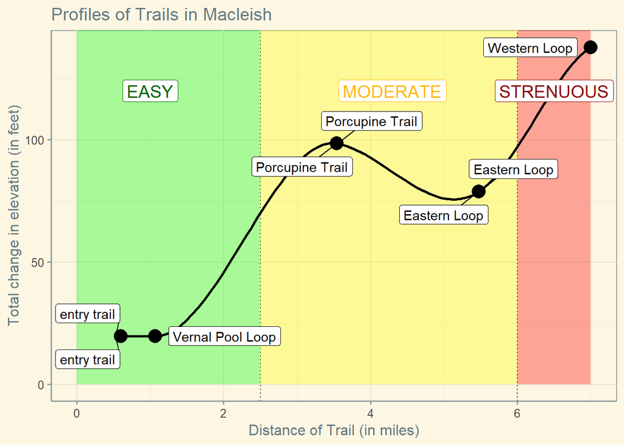

```r
elevation_graph
```

Based on our findings, we recommend that Smith College adds new markers to each of their trails to give visitors more information about the difficulty level of each trail so that they can better decide which to take. Each trail should be labeled “easy”, “moderate”, or “strenuous” based on length and changes in elevation. MacLeish Field Station should add a sign outlining each trail and saying which difficulty level each is, and then include descriptions of each difficulty level and what each means. “Easy” means the trail is suggested for those who prefer a leisurely walk, children, or people with mobility issues. The trails marked “moderate” are suggested to beginner hikers or people looking for a bit of casual exercise. The “strenuous” trails are suggested for experienced hikers or people looking for a challenge or an intense workout. This sign and details would be very helpful to visitors as they would be more satisfied with their time at MacLeish.

It would not take extensive resources for Smith to implement this sign marker at MacLeish. It will cost some money to get a sign made, but not too much because only one sign would be needed rather than new signs or markers throughout to entire Field Station.(if each sign costs between $10-$20 and we have a sign per trail the total would be under$100) This also means that it will take a very short period of time (around 2 days if there are enough student volunteers), as once the sign is made it will just need to be put up. Because this project does not require creating new spaces or sites on the Field Station, but rather is simply a mark. There s a limited number of signs so there won’t be any harm on the environment. We don’t see any major roadblocks to the implementation of our solutions.

> Word count: 798
[^1]: https://github.com/niannucci/MP3-Macleish